# Отчёт по лабораторной работе №8

Настройка SMTP-сервера

Бызова Мария Олеговна

2025-10-20

# Цель работы

## Цель работы

Целью данной лабораторной работы является приобретение практических навыков по установке и конфигурированию SMTP- сервера.

# Задание

## Задание

1. Установить на виртуальной машине server SMTP-сервер postfix.
2. Сделать первоначальную настройку postfix при помощи утилиты postconf, задав отправку писем не на локальный хост, а на сервер в домене.
3. Проверить отправку почты с сервера и клиента.
4. Сконфигурировать Postfix для работы в домене. Проверить отправку почты с сервера и клиента.
5. Написать скрипт для Vagrant, фиксирующий действия по установке и настройке Postfix во внутреннем окружении виртуальной машины server. Соответствующим образом внести изменения в Vagrantfile.

# Выполнение лабораторной работы

## Установка Postfix

Загрузим нашу операционную систему и перейдём в рабочий каталог с проектом. Далее запустим виртуальную машину server (рис. 1)

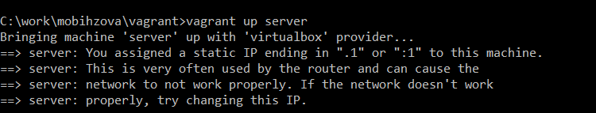

Рисунок 1: Запуск виртуальной машины server

## Установка Postfix

На виртуальной машине server войдём под нашим пользователем и откроем терминал. Далее перейдём в режим суперпользователя и установим необходимые для работы пакеты (рис. 2)

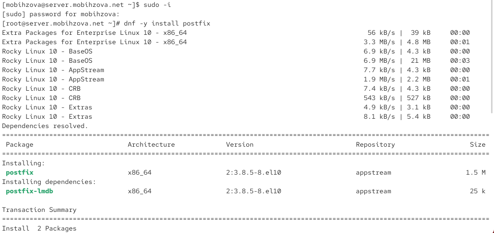

## Установка Postfix

Установим почтовый клиент s-nail (рис. 3)

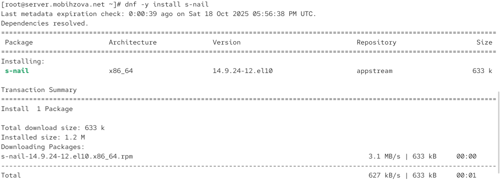

Рисунок 3: Установка почтового клиента s-nail

## Установка Postfix

Сконфигурируем межсетевой экран, разрешив работать службе протокола SMTP, восстановим контекст безопасности в SELinux и запустим Postfix (рис. 4)

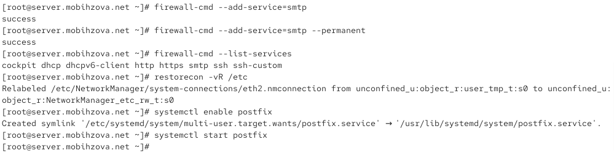

Рисунок 4: Настройка firewall, SELinux и запуск Postfix

## Изменение параметров Postfix с помощью postconf

Просмотрим список текущих настроек Postfix (рис. 5)

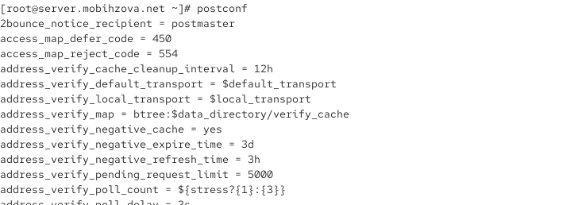

Рисунок 5: Просмотр текущих настроек Postfix

## Изменение параметров Postfix с помощью postconf

Посмотрим текущие значения параметров myorigin и mydomain, затем заменим значение параметра myorigin на значение параметра mydomain (рис. 6)

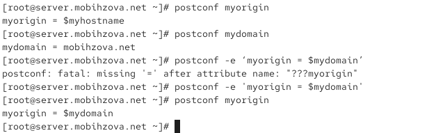

Рисунок 6: Настройка параметров myorigin и mydomain

## Изменение параметров Postfix с помощью postconf

Просмотрим все параметры с значением, отличным от значения по умолчанию (рис. 7)

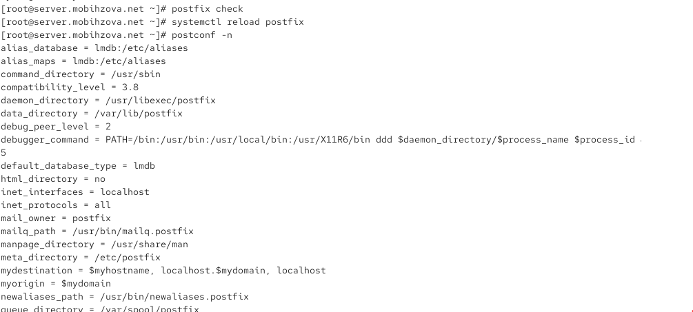

Рисунок 7: Параметры Postfix с нестандартными значениями

## Изменение параметров Postfix с помощью postconf

Зададим жёстко значение домена и отключим IPv6 в списке разрешённых протоколов (рис. 8)

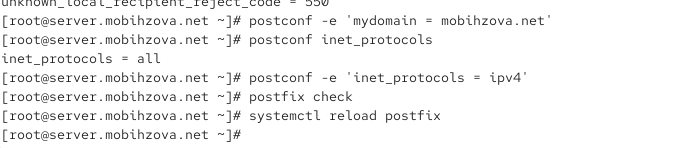

Рисунок 8: Настройка домена и протоколов

## Проверка работы Postfix

На сервере под учётной записью пользователя отправим себе письмо (рис. 9)

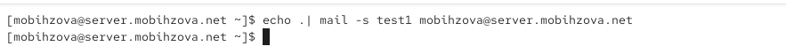

Рисунок 9: Отправка письма с сервера

## Проверка работы Postfix

Запустим мониторинг работы почтовой службы и посмотрим, что произошло с сообщением (рис. 10)

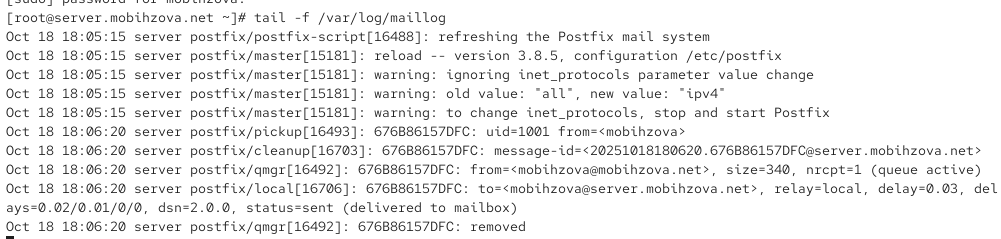

Рисунок 10: Мониторинг почтовой службы на сервере

## Проверка работы Postfix

Проверим содержание каталога /var/spool/mail (рис. 11)

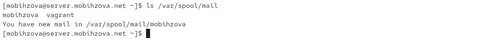

Рисунок 11: Проверка почтового ящика на сервере

## Проверка работы Postfix

На виртуальной машине client установим необходимые для работы пакеты ((рис. 12), (рис. 13)).

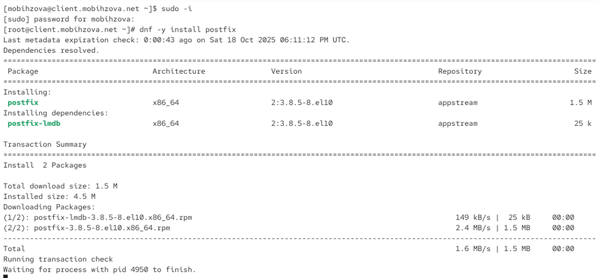

Рисунок 12: Установка postfix на клиенте

## Проверка работы Postfix

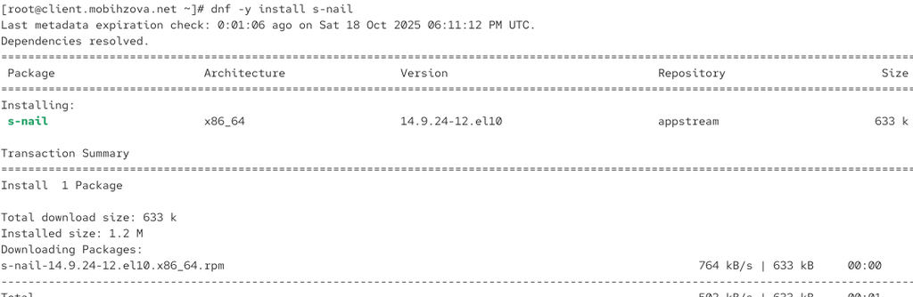

Рисунок 13: Установка s-mail на клиенте

## Проверка работы Postfix

Запустим мониторинг работы почтовой службы на клиенте (рис. 15)

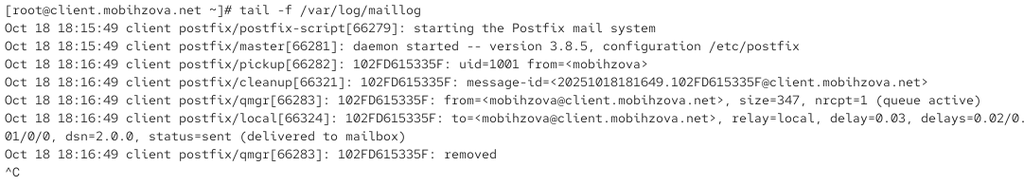

Рисунок 15: Мониторинг почтовой службы на клиенте

## Проверка работы Postfix

На сервере в конфигурации Postfix посмотрим значения параметров сетевых интерфейсов и настроим их для работы в сети (рис. 16)

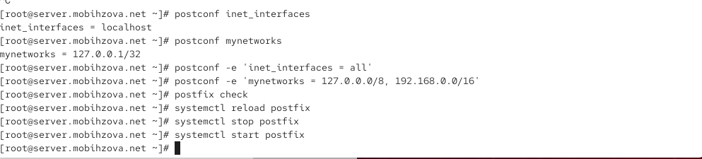

Рисунок 16: Настройка сетевых параметров Postfix

## Проверка работы Postfix

Проверим результат отправки в логах (рис. 18)

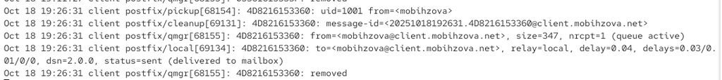

Рисунок 18: Результат отправки письма после настройки сети

## Конфигурация Postfix для домена

С клиента отправим письмо на свой доменный адрес (рис. 19)

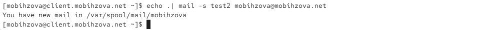

Рисунок 19: Отправка письма на доменный адрес

## Конфигурация Postfix для домена

Запустим мониторинг работы почтовой службы - видим ошибку DNS (рис. 20)

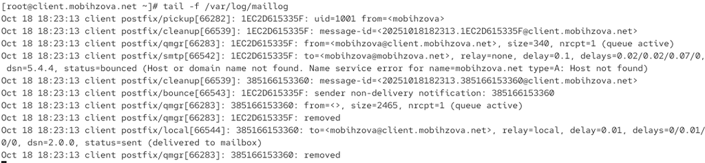

Рисунок 20: Ошибка DNS при отправке на домен

## Конфигурация Postfix для домена

Проверим очередь сообщений - она пустая (рис. 21)

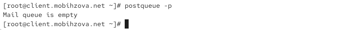

Рисунок 21: Проверка очереди сообщений

## Конфигурация Postfix для домена

Создадим файлы DNS-зон - прямую (рис. 22) и обратную (рис. 23)

## Конфигурация Postfix для домена

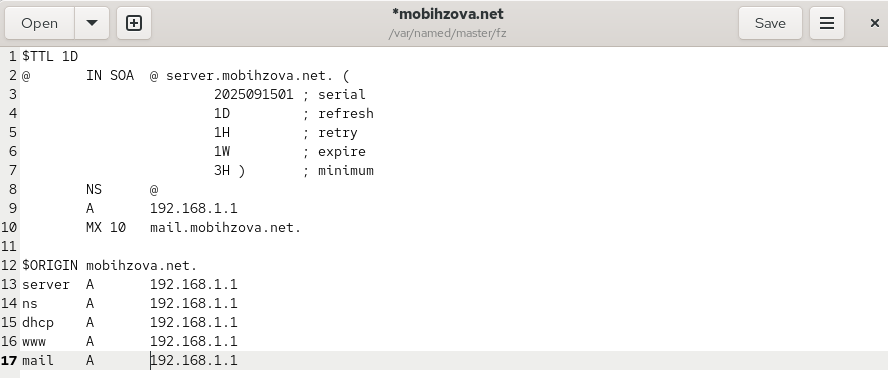

Рисунок 22: Прямая DNS-зона

## Конфигурация Postfix для домена

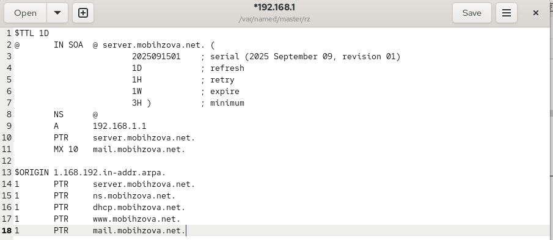

Рисунок 23: Обратная DNS-зона

## Конфигурация Postfix для домена

В конфигурации Postfix добавим домен в список элементов сети (рис. 24)

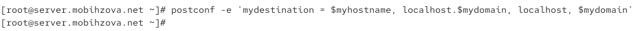

Рисунок 24: Добавление домена в mydestination

## Конфигурация Postfix для домена

Перезагрузим конфигурацию Postfix и DNS (рис. 25)

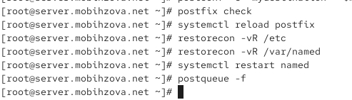

Рисунок 25: Перезагрузка служб

## Конфигурация Postfix для домена

Попробуем отправить сообщения, находящиеся в очереди, и проверим отправку почты с клиента на доменный адрес (рис. 26)

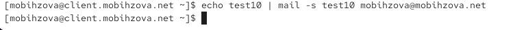

Рисунок 26: Отправка тестового письма после настройки DNS

## Конфигурация Postfix для домена

Проверим результат в логах - письмо успешно доставлено (рис. 27)

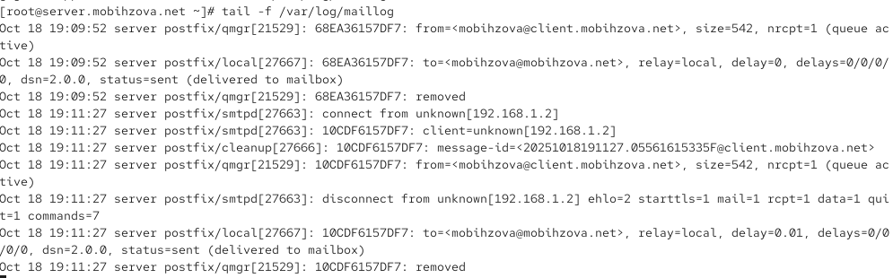

Рисунок 27: Успешная доставка доменной почты

## Внесение изменений в настройки внутреннего окружения виртуальной машины

Заменим конфигурационные файлы DNS-сервера и создадим исполняемый файл mail.sh на сервере (рис. 28)

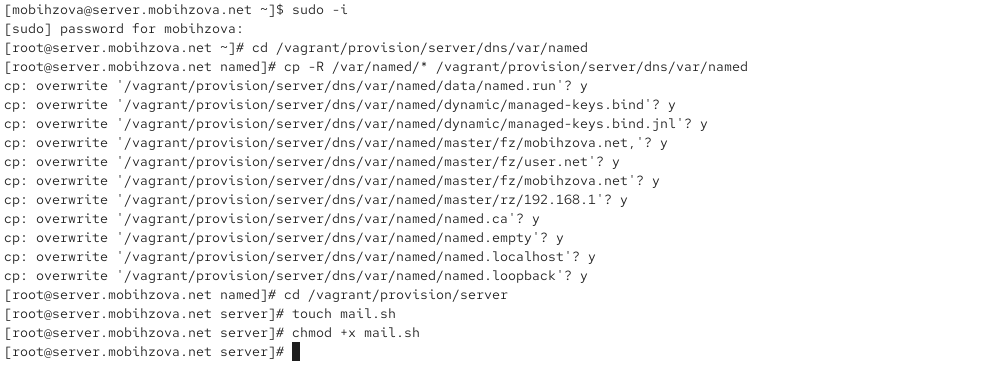

Рисунок 28: Копирование DNS-файлов и создание скрипта на сервере

## Внесение изменений в настройки внутреннего окружения виртуальной машины

Создадим скрипт для автоматической настройки почты на сервере (рис. 29)

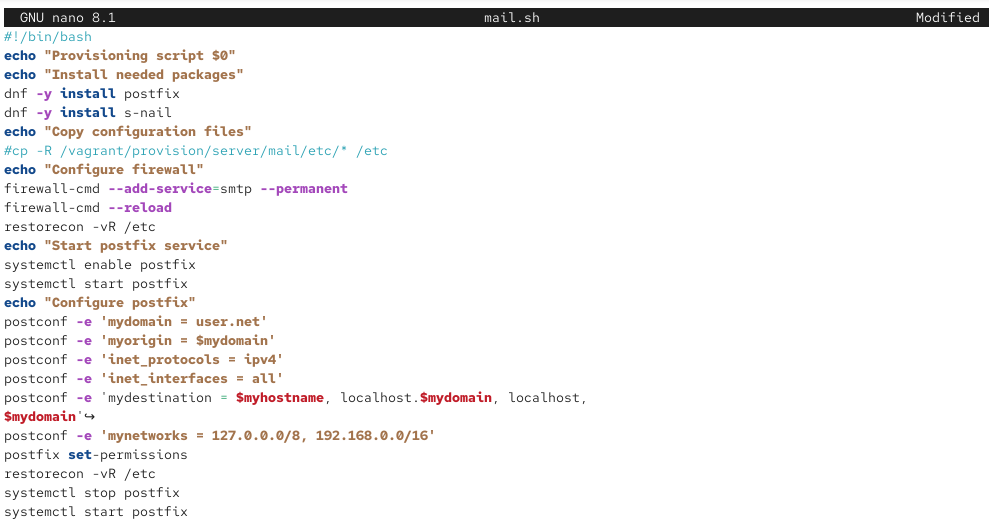

Рисунок 29: Скрипт настройки почты для сервера

## Внесение изменений в настройки внутреннего окружения виртуальной машины

Создадим исполняемый файл mail.sh на клиенте (рис. 30)

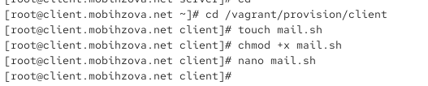

Рисунок 30: Создание скрипта на клиенте

## Внесение изменений в настройки внутреннего окружения виртуальной машины

Настроим скрипт для автоматической настройки почты на клиенте (рис. 31)

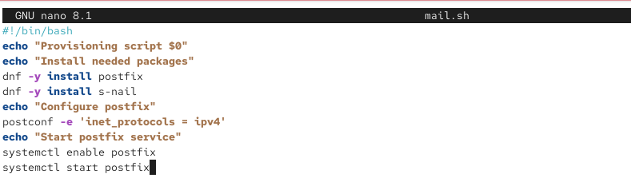

Рисунок 31: Скрипт настройки почты для клиента

## Внесение изменений в настройки внутреннего окружения виртуальной машины

Добавим в конфигурационный файл Vagrantfile provision для сервера (рис. 32)

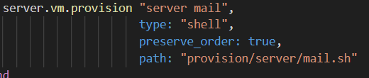

Рисунок 32: Provision для сервера в Vagrantfile

## Внесение изменений в настройки внутреннего окружения виртуальной машины

Добавим в конфигурационный файл Vagrantfile provision для клиента (рис. 33)

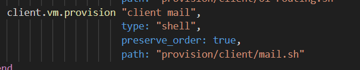

Рисунок 33: Provision для клиента в Vagrantfile

# Выводы

## Выводы

В ходе выполнения данной лабораторной работы я приобрела практические навыки по установке и конфигурированию SMTP-сервера.

# Список литературы

## Список литературы

1. Postfix Documentation. — URL: http://www.postfix.org/documentation.html